# VL02: Suche (BS, TS, BB, A*)

IFM 5.6 Künstliche Intelligenz, 2017/18

Carsten Gips, FH Bielefeld

# Wiederholung

## Problemlösen und Suche

- Was ist ein Problem?
- Was ist ein Suchbaum? Wo liegt der Unterschied zum Problemgraphen?
- Muss der Suchbaum als eine eigene Datenstruktur realisiert werden?
- Was bedeutet “optimal” und “vollständig” im Zusammenhang mit einem Suchalgorithmus?

# Motivation

## Finde einen Weg von Rimnicu Vilcea nach Bucharest

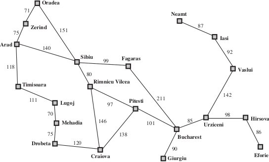

Quelle: [AIMA 3rd ed.](http://aima.cs.berkeley.edu)

=> Problemlösen == Suche im Graphen

## Themen für heute

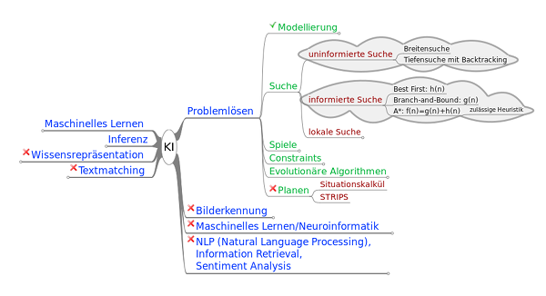

Am Ende der VL können/verstehen Sie:

- Verfahren der blinden Suche: Breiten- und Tiefensuche
- Verfahren der informierten Suche: Branch-and-Bound, Best-First, $A^\star$

# Uninformierte Suche

## Uninformierte (“blinde”) Suche

Keine Informationen über die Kosten eines Pfades: Nur die Pfadlänge zählt.

- Tiefensuche
- Breitensuche

## Erinnerung Tree-Search

1. Füge Startknoten in leere Datenstruktur (Stack, Queue, …) ein
2. Entnimm Knoten aus der Datenstruktur:
   1. Knoten ist gesuchtes Element: Abbruch, melde “*gefunden*”
   2. Expandiere alle Nachfolger des Knotens und füge diese in die Datenstruktur ein
3. Falls die Datenstruktur leer ist: Abbruch, melde “*nicht gefunden*”
4. Gehe zu Schritt 2

=> Was passiert, wenn wir einen Stack einsetzen?

Tafelbeispiel Tiefensuche (Stack, Suchbaum, Backtracking, Zyklen)

- Nachfolger eines Knotens: Von diesem Zustand durch Aktionen erreichbare Zustände
- Suchalgorithmus mit Stack als Datenstruktur => **Tiefensuche**
  - Zu betrachtender Knoten in Schritt 2 wird *oben* vom Stack genommen
  - Expandierte Knoten werden in Schritt 2.a *oben* auf den Stack gelegt
    - Dabei i.A. definierte Reihenfolge der Nachfolgeknoten beachten!

  Auswirkung: Weg wird in die **Tiefe** verfolgt (deshalb “Tiefensuche”)
- **Backtracking**: Wenn der Weg in eine Sackgasse führt, d.h. ein Knoten keine Nachfolger hat, werden bei der Expansion des Knotens keine Nachfolger auf den Stack gepackt. Die Evaluation des nächsten Knotens auf dem Stack bewirkt deshalb ein *Zurückspringen* im Suchbaum zum letzten Knoten auf dem aktuellen Weg mit noch offenen Alternativen …

  *Hinweis*: Im AIMA wird der Begriff “Backtracking” für den rekursiven Tiefensuche-Algorithmus verwendet. Dies steht im Gegensatz zum üblichen Sprachgebrauch in der KI!
- Vorsicht: Bei Tree-Search werden bereits besuchte Knoten u.U. immer wieder besucht. Zyklen im aktuell entwickelten Pfad sind also möglich!
- Anmerkung: Für Handsimulation besserer Überblick, wenn statt der Knoten immer partielle Wege im Stack gespeichert werden!
- Anmerkung: Im AIMA wird die Datenstruktur zum Halten der zu expandierenden Knoten (also hier im Fall der Tiefensuche der Stack) auch “**Frontier**” genannt.

## Tiefensuche (rekursive Variante)

1. Startknoten ist gesuchtes Element: Abbruch, melde “*gefunden*”
2. Für jeden Nachfolger des Startknotens:
   1. Rufe Tiefensuche für aktuellen (Nachfolger-) Knoten auf
   2. Ergebnis “*gefunden*”: Abbruch, melde “*gefunden*”
3. Abbruch, melde “*nicht gefunden*”
- Eigenschaften wie “normale” Tiefensuche
- Einfacher zu implementieren: Nutzung des Stacks wird auf den Compiler verlagert (Funktionsaufruf, Stack des Prozesses …)
- Speicherbedarf: Für jeden Knoten wird nur der nächste Knoten expandiert, plus Speicher für die Funktion

## Erinnerung Graph-Search

1. Füge Startknoten in leere Datenstruktur (Stack, Queue, …) ein
2. Entnimm Knoten aus der Datenstruktur:
   1. Knoten ist gesuchtes Element: Abbruch, melde “*gefunden*”
   2. Markiere aktuellen Knoten, und
   3. Expandiere alle Nachfolger des Knotens und füge alle unmarkierten Nachfolger, die noch nicht in der Datenstruktur sind, in die Datenstruktur ein
3. Falls die Datenstruktur leer ist: Abbruch, melde “*nicht gefunden*”
4. Gehe zu Schritt 2

=> Was passiert, wenn wir eine Queue einsetzen?

Tafelbeispiel Breitensuche (Queue, Suchbaum, markierte Knoten)

- Nachfolger eines Knotens: Von diesem Zustand durch Aktionen erreichbare Zustände
- Suchalgorithmus mit Queue als Datenstruktur => **Breitensuche**
  - Zu betrachtender Knoten in Schritt 2 wird *vorn* aus der Queue genommen
  - Expandierte Knoten werden in Schritt 2.a *hinten* in die Queue eingefügt
    - Dabei i.A. definierte Reihenfolge der Nachfolgeknoten beachten!

  Auswirkung: Suchbaum wird *ebenenweise* aufgebaut (deshalb “Breitensuche”)
- Markierte Knoten müssen geeignet gespeichert werden: separate Datenstruktur => Aufwand!
- *Hinweis*: Im AIMA wird die Breitensuche ebenfalls auf der Basis des Graph-Search-Algorithmus eingeführt. Allerdings wird die Abbruchbedingung modifiziert: Die Zielbedingung wird nicht erst (wie bei Graph-Search eigentlich definiert) geprüft, wenn ein Knoten aus der Queue entnommen wird, sondern bereits bei der Erzeugung der Nachfolgerknoten (vor dem Einfügen in die Queue). Dadurch spart man sich die Expansion einer zusätzlichen Ebene: Die Komplexität wäre in diesem Fall “nur” $O(b^{d})$.
- Anmerkung: Für Handsimulation besserer Überblick, wenn statt der Knoten immer partielle Wege in Queue gespeichert werden!

## Eigenschaften Breitensuche vs. Tiefensuche

|  | **Tiefensuche** | **Breitensuche** |
| --- | --- | --- |
| Vollständigkeit | nein[^1] | ja[^2] |
| Optimalität | nein | ja |
| Zeitkomplexität | $O(b^m)$ | $O(b^{d+1})$ |
| Speicherkomplexität | $O(bm)$ | $O(b^{d+1})$ |

- Zeitkomplexität: maximal zu expandierende Knotenzahl
- Speicher:
  - TS: in jeder Tiefe weitere $b$ Knoten speichern
  - BS: alle Knoten einer Ebene im Speicher halten[^3]

**b**: Verzweigungsfaktor, **d**: Ebene d. höchsten Lösungsknotens, **m**: Länge d. längsten Pfades

## Praxisvergleich Breitensuche vs. Tiefensuche

**Breitensuche**: Annahme: $b=10$, 10.000 Knoten/s, 1.000 Byte/Knoten

| **Tiefe** | **exp. Knoten** | **Zeit** | **Speicher** |
| --- | --- | --- | --- |
| 2 | $10^3$ | 0.1 s | 1 MB |
| 4 | $10^5$ | 10 s | 100 MB |
| 6 | $10^7$ | 20 min | 10 GB |
| 8 | $10^9$ | 30 h | 1 TB |
| 10 | $10^{11}$ | 130 d | 100 TB |

**Tiefensuche**: Annahme: längster Pfad $m=1000$

=> Speicherbedarf ca. 10 MB

nach Russell, Norvig: “Artificial Intelligence: A Modern Approach, 2nd ed.”

# Informierte Suche

## Informierte Suche: Nutzung der Kostenfunktion

**Gesamtkosten**: $f(n) = g(n) + h(n)$

- $n \in S$ auf aktuellem Weg erreichter Knoten
- $g(n)$ tatsächliche Kosten für Weg vom Start bis Knoten $n$
- $h(n)$ geschätzte Restkosten für Weg von Knoten $n$ zum Ziel

  => $h(n)$ wird auch “heuristische Funktion” oder “Heuristik” genannt

## Branch-and-Bound

Variante der Breitensuche mit Kosten

- Taucht im AIMA als “Uniforme Suche” auf: Alle Kosten sind gleich
- Funktioniert aber auch mit beliebigen *positiven* Kosten, d.h. falls für jeden Knoten $n$ gilt: $g(\operatorname{successor}(n)) \ge g(n)$
- Idee: Expandiere den *bisher* günstigsten partiellen Weg
- Kostenfunktion: $f(n) = g(n)$
- Datenstruktur: **sortierte Queue** (Prioritätsqueue)
- Voraussetzung: alle Aktionen haben positive Kosten

## BnB: Finde einen Weg von Rimnicu Vilcea nach Bucharest

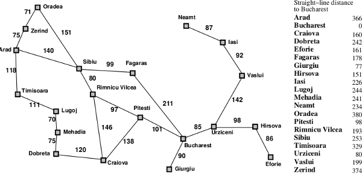

Quelle: [AIMA 3rd ed.](http://aima.cs.berkeley.edu)

Tafelbeispiel Branch-and-Bound (Graph-Search)

### Anmerkung zu BnB mit Graph-Search

Graph-Search fordert: Expandierte Nachfolgerknoten, die schon in der Queue sind, sollen nicht (erneut) in die Queue aufgenommen werden.

- Problem dabei: Was ist mit den Kosten?! Der neu expandierte Weg könnte günstiger sein als der schon in der Queue enthaltene.
- Vgl. Optimierungsmöglichkeiten für $A^\star$:
  - Füge zunächst alle neu expandierten partiellen Pfade in die Queue ein und behalte von mehreren Pfaden zum gleichen Knoten nur den günstigsten in der Queue
  - Pfade, deren Endknoten bereits früher im Pfad vorkommt (Schleifen), werden in Schritt 2 nicht in die Queue aufgenommen

Das Einfärben ist kein Problem, da nur der jeweils günstigste Knoten aus der Queue genommen, gefärbt und expandiert wird. D.h. alle anderen Wege sind zu diesem Zeitpunkt bereits teurer. Wenn man nun (später) über einen anderen Weg zu einem bereits gefärbten Knoten kommt, kann der neue Weg nicht günstiger sein (positive Kosten vorausgesetzt).

## Best-First

- Idee: Expandiere den partiellen Weg, der verspricht , dem Ziel am nächsten zu sein (**Heuristik**)
- Kostenfunktion: $f(n) = h(n)$
- Datenstruktur: **sortierte Queue** (Prioritätsqueue)
- Voraussetzungen: $h(n)$ positiv, $h(n)=0$ für den Zielknoten

Tafelbeispiel Best-First (Graph-Search)

## A*-Suche

- Kombination aus Branch-and-Bound und Best-First-Suche
- Kostenfunktion: $f(n) = g(n) + h(n)$
- Datenstruktur: **sortierte Queue** (Prioritätsqueue)
- Voraussetzung:
  1. Alle Aktionen haben positive Kosten
  2. Heuristik $h(n)$ muss zulässig/konsistent sein

Tafelbeispiel A* (Graph-Search, nur Anfang/Schreibweise)

## A*-Suche – Anforderungen an Heuristik

**Tree-Search-Variante**: Die Heuristik muss zulässig sein:

- Seien $h^\star(n)$ die tatsächlichen optimalen Restkosten von einem Knoten $n$ zum nächsten Ziel.
- Dann muss für jeden beliebigen Knoten $n$ gelten:
  $$h(n) \le h^\star(n).$$
- Ausserdem muss gelten:
  - $h(n) \ge 0$ für jeden Knoten $n$
  - $h(n)=0$ für jeden Zielknoten $n$

=> Beispiel: Luftlinie als Abschätzung

## A* ist optimal

$A^\star$ (Tree-Search-Variante) mit zulässiger Heuristik ist optimal.

Beweis siehe Übungsblatt B02 :-)

## Einfache Verbesserungen A* (Tree-Search)

- Dynamische Programmierung: Behalte von mehreren Pfaden zum gleichen Knoten nur den günstigsten in der Queue
- Pfade, deren Endknoten bereits früher im Pfad vorkommt (Schleifen), werden in Schritt 2 nicht in die Queue aufgenommen
- Übergang zur Graph-Search-Variante und Markierung von Knoten

  => Achtung: Dann schärfere Anforderungen an Heuristik (Konsistenz)

## A*-Suche – Anforderungen an Heuristik (cnt.)

**Graph-Search-Variante**: Die Heuristik muss konsistent sein:

Für jeden Knoten $n$ und jeden durch eine Aktion $a$ erreichten Nachfolger $m$ gilt:
$$h(n) \le c(n,a,m) + h(m)$$
mit $c(n,a,m)$ Schrittkosten für den Weg von $n$ nach $m$ mit Aktion $a$.

Ausserdem muss gelten:

- $h(n) \ge 0$ für jeden Knoten $n$
- $h(n)=0$ für jeden Zielknoten $n$

=> Eine konsistente Heuristik ist gleichzeitig zulässig.

## Eigenschaften Branch-and-Bound, Best-First, A*

|  | **Branch-and-Bound** | **Best-First** | **A*** |
| --- | --- | --- | --- |
| Kosten | $f(n) = g(n)$ | $f(n) = h(n)$ | $f(n) = g(n) + h(n)$ |
| Vollständigkeit | ja[^4] | nein[^5] | ja |
| Optimalität | ja | nein | ja |
| Aufwand | exponentiell | exponentiell | exponentiell |
| Bemerkung | Probiert erst alle “kleinen” Pfade durch | Suchverlauf stark abhängig von Heuristik | Heuristik: zulässig bzw. konsistent |

# Zusammenfassung

## tl;dr

- Uninformierte Suchverfahren
  - Keine weiteren Pfadkosten (nur Anzahl der Schritte)
  - Beispiele: Breiten- und Tiefensuche
- Informierte Suchverfahren
  - Nutzen reale Pfadkosten und/oder Schätzungen der Restkosten
  - Best-First: nur Schätzungen $h(n)$
  - Branch-and-Bound: nur reale Pfadkosten $g(n)$
  - A-Stern: komplette Kostenfunktion $f(n) = g(n)+h(n)$ => besondere Anforderungen an die Heuristik!
- Ausblick auf Verbesserungen der vorgestellten Suchverfahren:
  - Beschränkung der Suchtiefe (“Depth-Limited-Search”)
  - Iterative Vertieferung der Suchtiefe (“Iterative-Deepening-Search”), beispielsweise IDA* (“Iterative-Deepening A*“)
  - Beschränkung des verwendeten Speichers, beispielsweise SMA* (“Simplified Memory-Bounded A*“)

**Nächste Woche**: Lokale Suche (Gradientenabstieg, GA/EA)

## Literatur zum Weiterlesen

- Russell, Norvig: “Artificial Intelligence: A Modern Approach, 3rd ed.”
  - Uninformierte Suche: Kapitel 3.4
  - Best-First, $A^\star$: Kapitel 3.5
  - Branch-and-Bound/Uniforme Suche: Abschnitt 3.4.2
  - Heuristiken: Kapitel 3.6

## Lernziele – Nach dieser Vorlesung sollten Sie …

### Verstehen (K2)

- Breiten- und Tiefensuche, Branch-and-Bound, Best-First, $A^\star$:
  - Verwendete Datenstrukturen
  - Algorithmische Abläufe, Terminierung
  - Optimalität, Vollständigkeit und Komplexität
- Bedingung(en) an Restkostenabschätzung bei $A^\star$
- Bedeutung nicht-negativer Kosten für Branch-and-Bound

### Anwenden (K3)

- Uninformierte Suchverfahren: Breitensuche, Tiefensuche
- Informierte Suchverfahren Best-First, Branch-and-Bound, $A^\star$

## Diese Fragen sollten Sie beantworten können …

### Uninformierte Suche

- Zeichnen Sie den Suchbaum für eine Breiten- oder Tiefensuche für einen Weg von Urzizeni nach Craiova. Ist die Lösung optimal?
- Was bedeutet “optimal” im Zusammenhang mit der Suche? Ist Breitensuche optimal? Was ist der Unterschied zu “vollständig”?
- Wie kann man mit Tiefensuche den optimalen Weg finden?
- Was bedeutet Backtracking? Wie wird das implementiert?
- Findet Breitensuche immer eine Lösung, wenn es eine gibt? Ist die erste gefundene Lösung auch immer die optimale?
- Was ist das Problem an Breitensuche?

### A*-Suche

- Was passiert bei $A^\star$, wenn für alle Knoten $n$ gilt: $h(n)=0$?
- Begründen Sie, warum $A^\star$ (unter bestimmten Bedingungen) optimal ist?
- Finden Sie einen Weg von Lugoj nach Bukarest mit Hilfe von $A^\star$. Geben Sie die Queue in den Zwischenschritten an.

### Wahr oder falsch?

- Breitensuche ist ein Spezialfall von Branch-and-Bound.
- Tiefensuche ist ein Spezialfall von Best-First (Tree-Search-Variante).
- Branch-and-Bound ist ein Spezialfall von $A^\star$.
[^1]: gilt für Tree-Search-Variante; vollständig in Graph-Search-Variante bei endlichem Suchraum
[^2]: falls *b* endlich
[^3]: $O(b^{d})$ mit vorgezogener Zielprüfung (vgl. AIMA)
[^4]: BnB vollständig: Kosten größer Epsilon (positiv)
[^5]: gilt für Tree-Search-Variante; vollständig bei Graph-Search und endlichen Problemräumen